# Migration and remittances — a guide to the data

Diversity in a Globalized World

Published

September 9, 2026

# What this data is about

In the other sessions of this course, things moved: goods crossed borders, factories closed, technology arrived. In this one, **people move.**

About 281 million people live in a country they were not born in. That is around 3.6% of humanity — a small share, but it is not spread evenly. In some countries almost nobody living there was born abroad. In others, most of the people in the country came from somewhere else.

That 281 million is the published world total (UN DESA, 2020). If you add up the 216 countries in this file you get about 274 million instead. The gap is small territories and a handful of countries with no figure. Worth knowing: a total you compute from a file will rarely match the headline number exactly, and saying which one you used is part of doing this well.

And migration has a second half that is easy to forget. People who leave often send money home. Those payments — remittances — are now larger than all foreign aid combined, and for some countries they are a substantial part of the entire economy.

So there are two sides to look at: **where people go**, and **where the money goes back to**. They are not the same map.

**This folder covers 216 countries, 1990 to 2023.**

# The two files

| File | Use it for | What one row is |
| --- | --- | --- |
| `countries.rds` | **Maps** | One country, in 2020 |
| `migration_panel.rds` | **Change over time** | One country, one year |

```r
library(sf)
library(ggplot2)

countries <- readRDS("preprocessed_data/countries.rds")
panel     <- readRDS("preprocessed_data/migration_panel.rds")
```

# `countries.rds` — for maps

One row per country, with its shape attached. All values are for **2020**, the most recent year with migration figures.

```r
countries |>
  st_drop_geometry() |>
  filter(iso3 %in% c("MEX","USA","ARE","PHL")) |>
  select(country, migrants_pct, remittances_pct_gdp, net_migration)
```

```
               country migrants_pct remittances_pct_gdp net_migration
1        United States         14.9               0.032        329769
2 United Arab Emirates         76.0                  NA         92541
3          Philippines          0.1               9.643        -47014
4               Mexico          1.1               3.923       -147456
```

| Variable | What it means |
| --- | --- |
| `iso3`, `country`, `region`, `income` | Country code, name, world region, income group |
| `migrants_living_here` | Number of people living here who were born abroad |
| `migrants_pct` | The same, as % of the country’s population |
| `net_migration` | People arriving minus people leaving. **Negative = more left than came** |
| `remittances_pct_gdp` | Money sent home by citizens abroad, as % of GDP |
| `remittances_usd` | The same, in US dollars |
| `migrants_pct_change` | Change in `migrants_pct` since 1990 |
| `gdp_per_capita`, `population` | Context |
| `geometry` | The country’s shape — you never touch this directly |

**A map takes one line:**

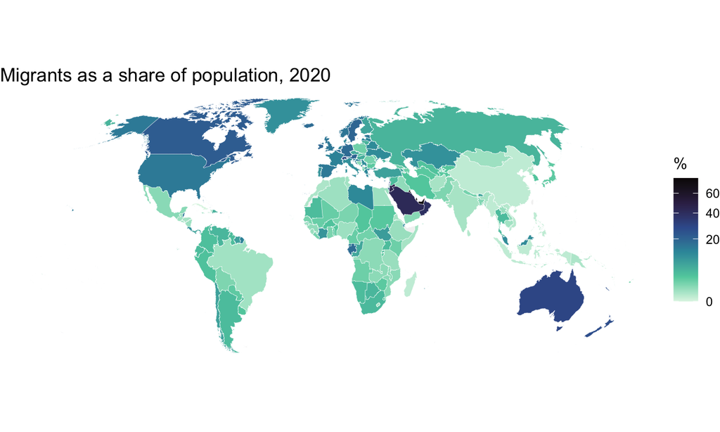

```r
ggplot(countries) +
  geom_sf(aes(fill = migrants_pct), color = "white", linewidth = 0.08) +
  scale_fill_viridis_c(option = "mako", direction = -1, trans = "sqrt",
                       na.value = "grey95", name = "%") +
  labs(title = "Migrants as a share of population, 2020") +
  coord_sf(crs = "+proj=robin") +
  theme_void()
```

# The thing to notice first

Now draw the second map — not where migrants live, but where the money goes back to.

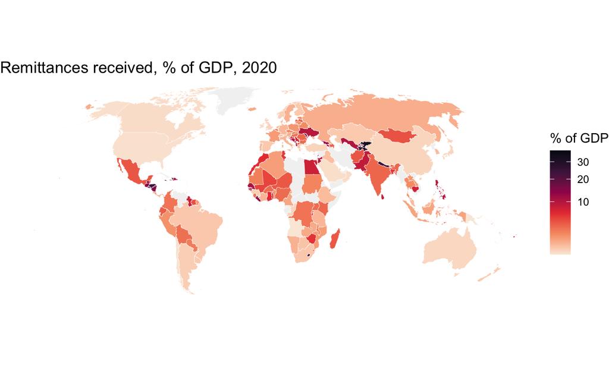

```r
ggplot(countries) +
  geom_sf(aes(fill = remittances_pct_gdp), color = "white", linewidth = 0.08) +
  scale_fill_viridis_c(option = "rocket", direction = -1, trans = "sqrt",
                       na.value = "grey95", name = "% of GDP") +
  labs(title = "Remittances received, % of GDP, 2020") +
  coord_sf(crs = "+proj=robin") +
  theme_void()
```

**These are almost opposite maps.** The Gulf states, North America, Western Europe and Australia are dark on the first. Central America, the Caucasus, West Africa, Nepal and the Philippines are dark on the second.

That is migration seen from both ends. One map shows the countries people arrive in. The other shows the countries they left, and still support.

Mexico is a good example of why one map is never enough. Only about **1%** of people living in Mexico were born abroad, so on the first map Mexico is pale — it looks like a country migration has barely touched. But remittances are around **4% of Mexican GDP**, and net migration is strongly negative. Mexico appears in this data mainly as a country people *leave*.

# `migration_panel.rds` — for change over time

Every year from 1990 to 2023, same variables.

```r
head(panel[panel$iso3 == "MEX", c("country","year","net_migration","remittances_pct_gdp")], 4)
```

```
     country year net_migration remittances_pct_gdp
4319  Mexico 2007       -105524               2.496
4320  Mexico 2017       -227499               2.765
4321  Mexico 2005       -310278               2.478
4322  Mexico 2016       -304472               2.637
```

**A line for one country:**

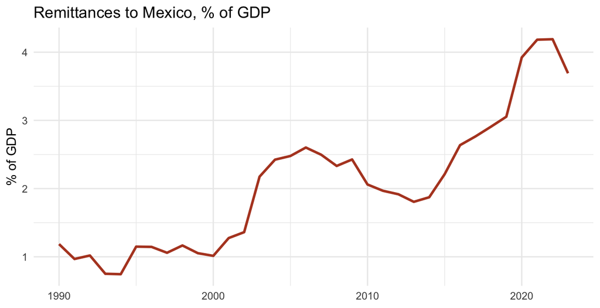

```r
mex <- panel[panel$iso3 == "MEX", ]

ggplot(mex, aes(year, remittances_pct_gdp)) +
  geom_line(color = "#b44527", linewidth = 1) +
  labs(title = "Remittances to Mexico, % of GDP",
       x = NULL, y = "% of GDP") +
  theme_minimal()
```

# Two things that will trip you up

**Migrant numbers only exist every five years.** The stock of migrants is measured in 1990, 1995, 2000, 2005, 2010, 2015 and 2020 — nothing in between. If you plot `migrants_pct` by year you will get seven points, not thirty. Remittances, population and net migration *are* annual.

**`migrants_pct` counts people living in a country, not people who left it.** There is no simple “% of this country’s citizens who emigrated” variable here. If you want to say something about a country people leave, use `net_migration` (negative means outflow) or `remittances_pct_gdp` as an indirect signal. Say which one you used and why.

# Other things worth knowing

**213 of 241 shapes have data.** Very small territories mostly do not appear.

**Remittances are recorded payments only.** Money carried home in cash or sent informally does not appear, so the real figures are higher — probably much higher in countries with weak banking systems.

**`income` groups countries** as low, lower-middle, upper-middle or high income. That is a useful thing to colour or facet by.

# Questions you could ask

- Which countries host the most migrants relative to their size, and what do they have in common?
- Do richer countries receive more migrants? Plot `gdp_per_capita` against `migrants_pct`.
- Which economies depend most on remittances, and are those the same countries people are leaving?
- Has Mexico’s dependence on remittances grown or shrunk since 1990? Does the line move with anything you recognise?
- Compare Central America with Southeast Asia. Same pattern, or different?
- Are there countries that both send and receive large numbers of migrants?
- Where did `migrants_pct` grow most since 1990, and does that match where the political argument about migration is loudest?

# Where the data comes from

World Bank World Development Indicators, via the `WDI` R package. Migrant stock figures originate with the UN Population Division; remittances with the IMF and national central banks. Country outlines from Natural Earth.

We kept 1990 to 2023, selected seven indicators, renamed them into plain English and attached the map shapes.